# Soluzione - Tutorato 4

## 🔹 Punto 5 - Analisi dei residui

1. Analizzare i residui del modello scelto: possiamo dire sia adeguato?

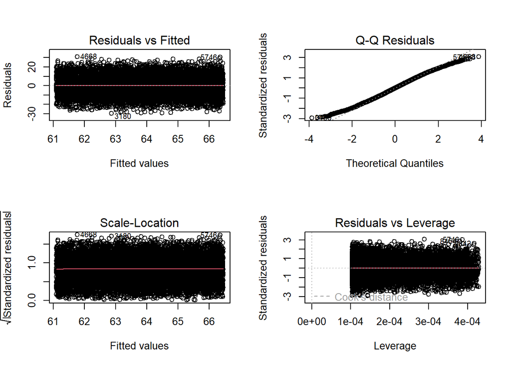

```r
# Grafici diagnostici del modello
par(mfrow = c(2, 2))
plot(mod3)
```

```r
# Test di normalità (usando Kolmogorov-Smirnov perché n > 5000)
ks.test(scale(residuals(mod3)), "pnorm")
```

```
##
##  Asymptotic one-sample Kolmogorov-Smirnov test
##
## data:  scale(residuals(mod3))
## D = 0.016958, p-value = 0.007975
## alternative hypothesis: two-sided
```

## 💥 Risposta

- **QQ plot**: i punti si discostano dalla retta nelle code → leggera non-normalità.
- **Residui vs fitted**: dispersione abbastanza costante → omoschedasticità accettabile.
- **Scale-Location**: trend piatto → varianza costante.
- **Residui vs Leverage**: nessun punto oltre la distanza di Cook → nessun outlier influente.
- **Kolmogorov-Smirnov**: p-value < 0.05 → i residui **non sono perfettamente normali** (comune con campioni grandi).

Il modello è **accettabile** e i residui non presentano problemi gravi. La non-normalità è leggera e dovuta alla numerosità del campione.

## 🔹 Punto 6 - Confronto tra modelli

1. Costruire diversi modelli variando il regressore; come possiamo confrontarli? Quale sembra essere il più adeguato?

```r
# Modelli con diversi regressori
mod_att <- lm(overall_score ~ attendance_percentage, data = studenti_clean)
mod_study <- lm(overall_score ~ study_hours_per_day, data = studenti_clean)
mod_sleep <- lm(overall_score ~ sleep_hours, data = studenti_clean)
mod_assignment <- lm(overall_score ~ assignment_score, data = studenti_clean)
mod_midterm <- lm(overall_score ~ midterm_score, data = studenti_clean)
mod_final <- lm(overall_score ~ final_exam_score, data = studenti_clean)
mod_participation <- lm(overall_score ~ participation_score, data = studenti_clean)

# Modello con più variabili
mod_multi <- lm(overall_score ~ attendance_percentage + study_hours_per_day +
                sleep_hours + assignment_score + midterm_score +
                final_exam_score + participation_score,
                data = studenti_clean)

# Confronto R² aggiustati
summary(mod_att)$adj.r.squared
```

```
## [1] 0.02274119
```

```r
summary(mod_study)$adj.r.squared
```

```
## [1] -0.0001036594
```

```r
summary(mod_sleep)$adj.r.squared
```

```
## [1] -0.000103407
```

```r
summary(mod_assignment)$adj.r.squared
```

```
## [1] 0.1562826
```

```r
summary(mod_midterm)$adj.r.squared
```

```
## [1] 0.2781278
```

```r
summary(mod_final)$adj.r.squared
```

```
## [1] 0.4760289
```

```r
summary(mod_participation)$adj.r.squared
```

```
## [1] 0.05902064
```

```r
summary(mod_multi)$adj.r.squared
```

```
## [1] 1
```

```r
# AIC per confronto
AIC(mod_att, mod_study, mod_sleep, mod_assignment, mod_midterm,
    mod_final, mod_participation, mod_multi)
```

```
##                   df        AIC
## mod_att            3   71709.75
## mod_study          3   71931.72
## mod_sleep          3   71931.71
## mod_assignment     3   70298.30
## mod_midterm        3   68800.06
## mod_final          3   65722.18
## mod_participation  3   71346.35
## mod_multi          9 -529912.99
```